# Stafgildi í Skrafli

Stefán Ingi Valdimarsson

maí 2015

Hér verður leitast við að greina hvaða stafgildi hver stafur ætti að hafa í Skrafli og hver ætti að vera fjöldi hvers stafs í pokanum.

# Aðferðafræði

Sterkasti þjarkurinn í Netskraflinu (http://netskrafl.is) er látinn spila á móti sjálfum sér oft og mörgum sinnum. Þannig er útbúið gagnasafn sem er hægt að nota til að greina hvort stafgildin séu heppilega valin. Kóðinn fyrir þessu er á github, hlekkur verður settur inn þegar kóðinn er kominn í aðalskjalageymsluna.

# Núverandi stafgildi

## Lýsing gagna

Skráin `log0002.json` inniheldur upplýsingar um 3000 leiki. Upplýsingar úr henni eru lesnar inn í gagnarammann game.data. Í þeim ramma eru eftirfarandi dálkar:

- *Game.number:* Númer leiks
- *Player:* Heiti leikmanns, APA eða APB
- *Played.first:* Átti leikmaðurinn fyrsta leik
- *Is.winner:* Vann leikmaðurinn (eða gerði jafntefli)
- *Is.tie:* Varð jafntefli
- *Points:* Fjöldi stiga sem leikmaðurinn fékk, þar með talin stig vegna afgangsstafa
- *Any.returned:* Var stöfum einhvern tímann skilað í leiknum
- *First.returned:* Var stöfum skilað í fyrsta leik hjá leikmanninum sem átti fyrst að gera
- *Non.first.returned:* Var stöfum skilað síðar en í fyrsta leik hjá leikmanninum sem átti fyrst að gera
- *a-ö:* Fjöldi taflna af hverjum staf sem leikmaðurinn dró, ef einhverjum töflum er skilað þá eru þær tvítaldar í leiknum.
- *q:* Fjöldi auðra stafataflna sem leikmaðurinn dró, ef einhverjum töflum er skilað þá eru þær tvítaldar í leiknum.

## Áhrif stafsins ú

Eftirfarandi mynd sýnir úrslit leikja brotin niður eftir fjölda ú-a sem leikmaður fékk.

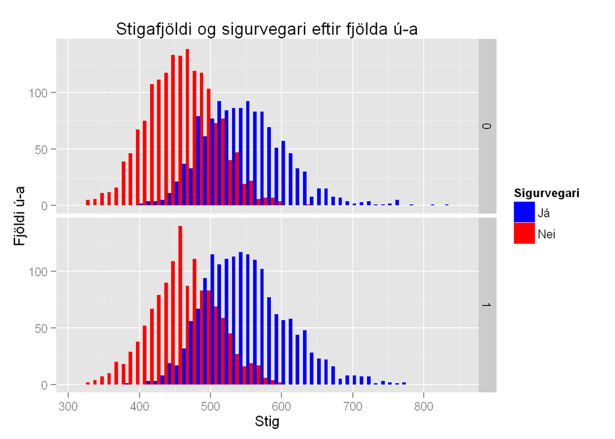

Greinilegt er af mynd að það að draga ú-ið er vænlegra til sigurs.

Nánar tiltekið eru metin líkindi þess að leikmaður sigri ef hann dregur ú 56,3% og 99% öryggisbil fyrir raunverulegu líkindin er [54%, 58,7%].

## Áhrif auðu taflnanna

Eftirfarandi mynd sýnir úrslit leikja brotin niður eftir fjölda auðra taflna sem leikmaður fékk.

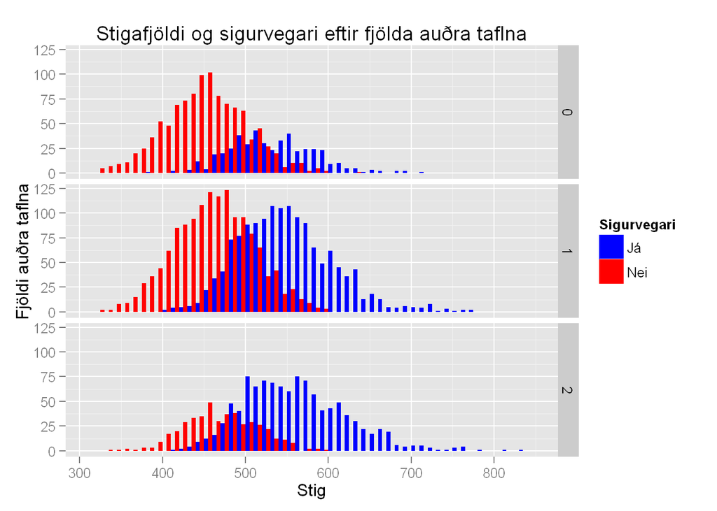

Greinilegt er af mynd að það að fá báðar auðu töflurnar eykur líkur á sigri gífurlega.

Nánar tiltekið eru metin líkindi þess að leikmaður sigri ef hann dregur báðar auðu töflurnar 70,7% og 99% öryggisbil fyrir raunverulegu líkindin er [67,7%, 73,7%].

## Áhrif þess að gera fyrst

Eftirfarandi mynd sýnir úrslit leikja brotin niður eftir því hvort leikmaður gerir fyrst eða ekki.

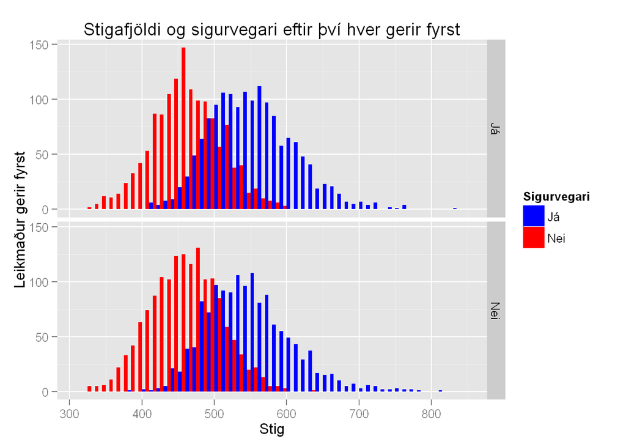

Ekki er mjög greinilegt af mynd hvort það að gera fyrst hefur veruleg áhrif á sigurlíkur.

En metin líkindi þess að leikmaður sigri ef hann gerir fyrst eru 52,7% og 99% öryggisbil fyrir raunverulegu líkindin er [50,3%, 55%].

## Niðurstöður

Það má velta fyrir sér hvort það þjóni tilgangi að fikta með stafgildin þegar áhrifin af auðu töflunum eru svona gífurleg.